[figure not shown]

**To Read**

[An Introduction to Statistical Learning](https://www.statlearning.com/) [Statistical Modeling: A Fresh Approach](https://dtkaplan.github.io/SM2-bookdown/)

```r
library(tidyverse)
library(modelr)
options(na.action = na.warn)

library(gapminder)
```

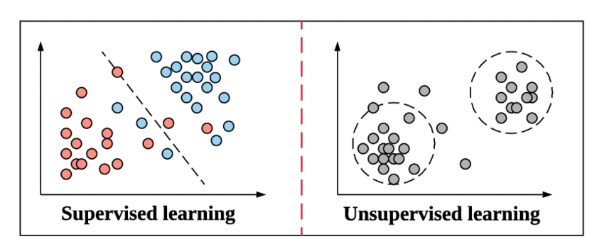

In **supervised** models, you first label some data (here “red” and “blue”) and then the model is fit to predict those labels in new, unlabeled values. In **unsupervised** models, unlabeled data is entered and the model categorizes it (which can then be used for new values).

# $\color{darkblue}{\textbf{Supervised}}$

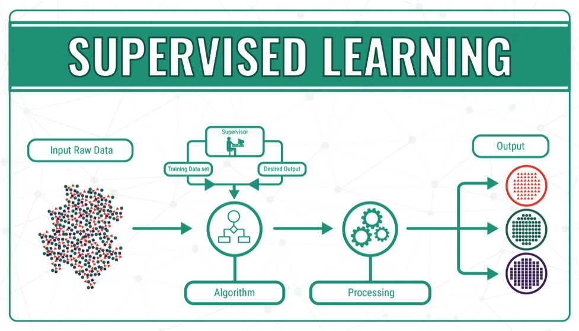

### $\color{dodgerblue}{\textbf{Linear Regression}}$

Linear models fit lines of $y = mx + b$ where $m$ is the slope and $b$ is the intercept.